# Post Lab Meeting

*28/Sep/2018*

I presented the chemostat model for loss of sporulation in lab meeting. Here I want to address some ideas that came up during the meeting.

# Invasion by mutant

Roy asked whether the spo<sup>-</sup> mutant would out compete also if it was introduced as a single cell rather than adding it theiugh a mutation parameter. I will try that here. First I need to get the model with the mutation parameter in here.

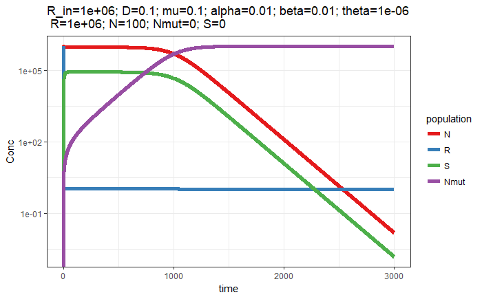

```r
chemostat1.mut <- function(t,current,params){
  with(as.list(c(params,current)), {
    #list the equations for the derivatives of each state variable
    #R is the resource
    dR <- D * (R_in - R) - mu * R * (N+Nmut)

    #N are the sporulating bacteria
    dN <- mu * R * N - D * N - alpha * N + beta * S - theta * N
    # Nmut are the spo- mutants
    dNmut <- mu * R * Nmut - D*Nmut +theta * N

    #S are the spores
    dS <- alpha * N - beta * S - D*S


    results <- c(dR, dN,dNmut, dS)
    return (list(results))
  })
}
# resource in inflow
R_in <- 1e6
#dilution rate
D <- 0.1
# growth rate
mu <- D
# probaility of sporulation
alpha <- 0.01
#probability of reactivation of spores
beta <- 0.01
#loss of sporulation by mutation
theta <- 1e-6
# all parameters together
params1 <- c(R_in=R_in, D=D, mu=mu, alpha=alpha, beta=beta,theta=theta)
#declare initial conditions for state variables
current1 <- c(R = R_in, N = 1e2, Nmut=0, S=0)
#define the time to run model
t <- seq (0, 3000, by=1)
#solve the model and save the output
out <- lsoda(current1, t, chemostat1.mut, params1)
# to long format for ggplot
out.l <- gather(as.data.frame(out), key='population', value='Conc', colnames(out)[-1])
out.l$population <- as.factor(out.l$population)
out.l$population <-factor(out.l$population, levels = c('N', 'R', 'S','Nmut'))
#save for comparison with second model
out.l_1 <- out.l
out.l_1$model <- "spo-loss mutation term"
# ggplot(out.l[out.l$population!='R',], aes(x=time, y=Conc))+
ggplot(out.l, aes(x=time, y=Conc))+
  geom_line(aes(color=population), size=2)+
  scale_y_log10()+
  theme_bw()+
  scale_colour_brewer(palette='Set1')+
  ggtitle(paste(
    paste0(paste(names(params1)),'=',paste(params1), collapse = '; '),'\n',
    paste0(paste(names(current1)),'=',paste(current1), collapse = '; ')))
```

Now I will modify it the way Roy suggested.

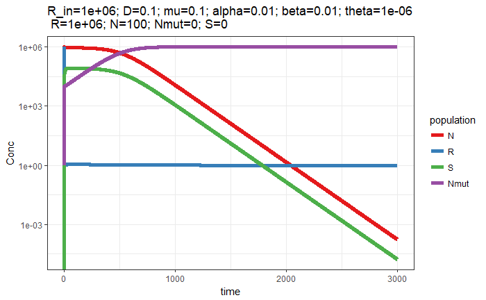

```r
chemostat1.inv <- function(t,current,params){
  with(as.list(c(params,current)), {
    #list the equations for the derivatives of each state variable
    #R is the resource
    dR <- D * (R_in - R) - mu * R * (N+Nmut)

    #N are the sporulating bacteria
    dN <- mu * R * N - D * N - alpha * N + beta * S
    # Nmut are the spo- mutants
    dNmut <- mu * R * Nmut - D*Nmut

    #S are the spores
    dS <- alpha * N - beta * S - D*S


    results <- c(dR, dN,dNmut, dS)
    return (list(results))
  })
}
# all parameters together with ou theta
params1.inv <- c(R_in=R_in, D=D, mu=mu, alpha=alpha, beta=beta)
#declare initial conditions for state variables
current1.inv <- c(R = R_in, N = 1e2, Nmut=1, S=0) #added Nmut=1!
#define the time to run model
t <- seq (0, 3000, by=1)
#solve the model and save the output
out <- lsoda(current1.inv, t, chemostat1.inv, params1.inv)
# to long format for ggplot
out.l <- gather(as.data.frame(out), key='population', value='Conc', colnames(out)[-1])
out.l$population <- as.factor(out.l$population)
out.l$population <-factor(out.l$population, levels = c('N', 'R', 'S','Nmut'))
# ggplot(out.l[out.l$population!='R',], aes(x=time, y=Conc))+
ggplot(out.l, aes(x=time, y=Conc))+
  geom_line(aes(color=population), size=2)+
  scale_y_log10()+
  theme_bw()+
  scale_colour_brewer(palette='Set1')+
  ggtitle(paste(
    paste0(paste(names(params1)),'=',paste(params1), collapse = '; '),'\n',
    paste0(paste(names(current1)),'=',paste(current1), collapse = '; ')))
```

The Wt is out competed even quicker. I will plot them together.

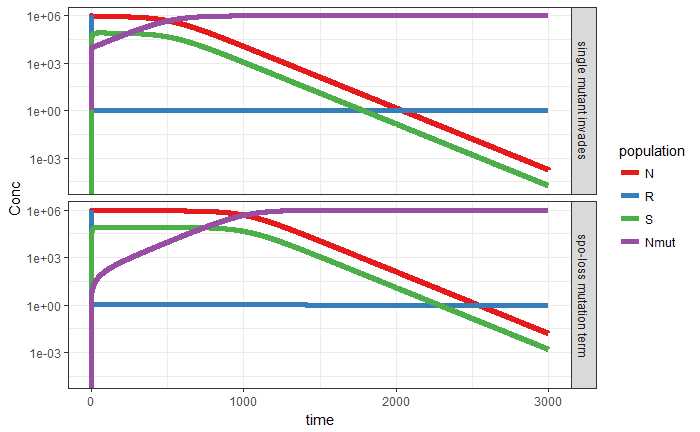

```r
out.l$model <- "single mutant invades"
#combine the output of the 2 models
out.l <- rbind(out.l,out.l_1)
#Plot together
ggplot(out.l, aes(x=time, y=Conc))+
  geom_line(aes(color=population), size=2)+
  scale_y_log10()+
  theme_bw()+
  scale_colour_brewer(palette='Set1')+
  facet_grid(model~.)
```

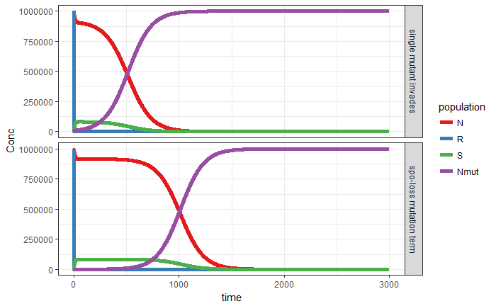

```r
ggplot(out.l, aes(x=time, y=Conc))+
  geom_line(aes(color=population), size=2)+
  # scale_y_log10()+
  theme_bw()+
  scale_colour_brewer(palette='Set1')+
  facet_grid(model~.)
```

In the inasion model the sporulator is out-competed quicker! That is likely because it is introduced at t=0 with 1% frequency. I’ll run both models again witn N at t=0 set to 10<sup>6</sup>.

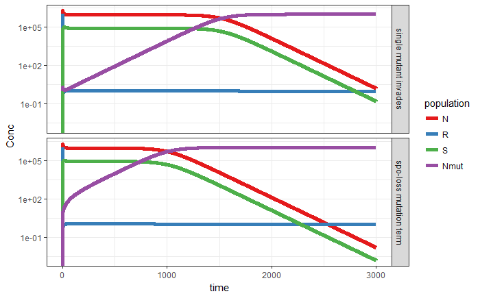

```r
#modify initial conditions
current1 <- c(R = R_in, N = 1e6, Nmut=0, S=0)
current1.inv <- c(R = R_in, N = 1e6, Nmut=1, S=0)
#solve the model and save the output
out <- lsoda(current1, t, chemostat1.mut, params1)
# to long format for ggplot
out.l <- gather(as.data.frame(out), key='population', value='Conc', colnames(out)[-1])
out.l$population <- as.factor(out.l$population)
out.l$population <-factor(out.l$population, levels = c('N', 'R', 'S','Nmut'))
#save for comparison with second model
out.l_1 <- out.l
out.l_1$model <- "spo-loss mutation term"
#solve the model and save the output
out <- lsoda(current1.inv, t, chemostat1.inv, params1.inv)
# to long format for ggplot
out.l <- gather(as.data.frame(out), key='population', value='Conc', colnames(out)[-1])
out.l$population <- as.factor(out.l$population)
out.l$population <-factor(out.l$population, levels = c('N', 'R', 'S','Nmut'))
out.l$model <- "single mutant invades"
#combine the output of the 2 models
out.l <- rbind(out.l,out.l_1)
#Plot together
ggplot(out.l, aes(x=time, y=Conc))+
  geom_line(aes(color=population), size=2)+
  scale_y_log10()+
  theme_bw()+
  scale_colour_brewer(palette='Set1')+
  facet_grid(model~.)
```

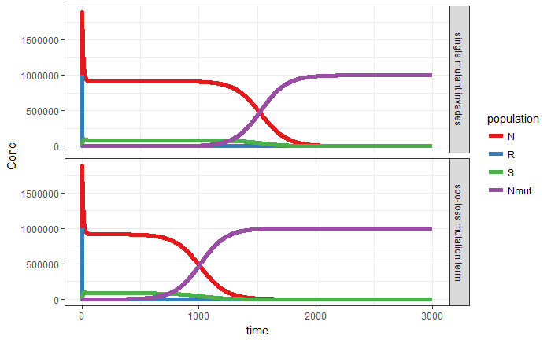

```r
ggplot(out.l, aes(x=time, y=Conc))+
  geom_line(aes(color=population), size=2)+
  # scale_y_log10()+
  theme_bw()+
  scale_colour_brewer(palette='Set1')+
  facet_grid(model~.)
```

Now it takes the invader longer to outcompete sporulator, but he does do so.

# Strength of viral selection

Another point raised by Roy in lab meeting was that perhaps if viral selection was greater than sporulation wpuld be sustained in the chemostat in face of mutant invasion. To tst this I will first add the virus into the mutant invasion model.

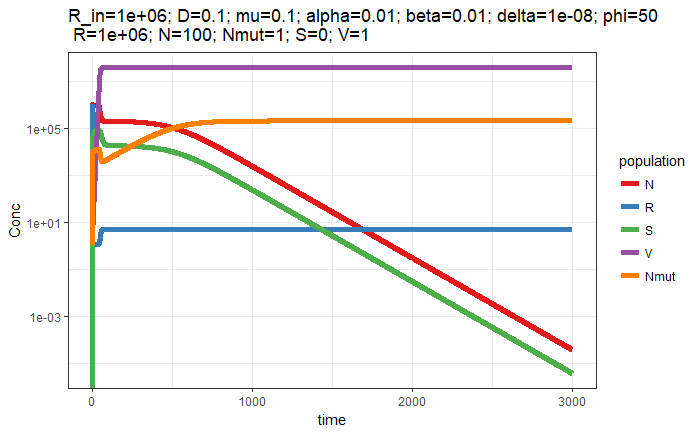

```r
chemostat1v.inv <- function(t,current,params){
  with(as.list(c(params,current)), {
    #list the equations for the derivatives of each state variable
    #R is the resource
    dR <- D * (R_in - R) - mu * R * (N+Nmut)

    #N are the sporulating bacteria
    dN <- mu * R * N - D * N - alpha * N + beta * S - delta * N * V
    # Nmut are the spo- mutants
    dNmut <- mu * R * Nmut - D*Nmut - delta * Nmut * V

    #S are the spores
    dS <- alpha * N - beta * S - D*S

    #V are the phages
    dV <- delta * (N+Nmut) * V * (phi-1) - D*V

    results <- c(dR, dN,dNmut,dS,dV)
    return (list(results))
  })
}
#adsorption constant rate (per hour per ml)
delta <- 1e-8
# busrt size
phi <- 50
# all parameters together with viral params
params1v.inv <- c(R_in=R_in, D=D, mu=mu, alpha=alpha, beta=beta, delta=delta, phi=phi)
#declare initial conditions for state variables
current1v.inv <- c(R = R_in, N = 1e2, Nmut=1, S=0, V=1) #added Nmut=1!
#define the time to run model
t <- seq (0, 3000, by=1)
#solve the model and save the output
out <- lsoda(current1v.inv, t, chemostat1v.inv, params1v.inv)
# to long format for ggplot
out.l <- gather(as.data.frame(out), key='population', value='Conc', colnames(out)[-1])
out.l$population <- as.factor(out.l$population)
out.l$population <-factor(out.l$population, levels = c('N', 'R', 'S', 'V','Nmut'))
# ggplot(out.l[out.l$population!='R',], aes(x=time, y=Conc))+
ggplot(out.l, aes(x=time, y=Conc))+
  geom_line(aes(color=population), size=2)+
  scale_y_log10()+
  theme_bw()+
  scale_colour_brewer(palette='Set1')+
  ggtitle(paste(
    paste0(paste(names(params1v.inv)),'=',paste(params1v.inv), collapse = '; '),'\n',
    paste0(paste(names(current1v.inv)),'=',paste(current1v.inv), collapse = '; ')))
```

I will now raise the phage load by increasing adsorption and burst size (100-fold each)

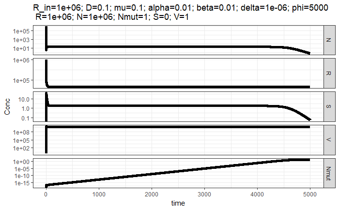

```r
# a variable to increase viral load
vl <- 100
#adsorption constant rate (per hour per ml)
delta <- 1e-8*vl
# busrt size
phi <- 50*vl
# all parameters together with viral params
params1v.inv <- c(R_in=R_in, D=D, mu=mu, alpha=alpha, beta=beta, delta=delta, phi=phi)
#declare initial conditions for state variables
current1v.inv <- c(R = R_in, N = 1e6, Nmut=1, S=0, V=1) #added Nmut=1!
#define the time to run model
t <- seq (0, 5000, by=1)
#solve the model and save the output
out <- lsoda(current1v.inv, t, chemostat1v.inv, params1v.inv)
# to long format for ggplot
out.l <- gather(as.data.frame(out), key='population', value='Conc', colnames(out)[-1])
out.l$population <- as.factor(out.l$population)
out.l$population <-factor(out.l$population, levels = c('N', 'R', 'S', 'V','Nmut'))
# ggplot(out.l[out.l$population!='R',], aes(x=time, y=Conc))+
ggplot(out.l, aes(x=time, y=Conc))+
  geom_line( size=2)+
  scale_y_log10()+
  theme_bw()+
  scale_colour_brewer(palette='Set1')+
  facet_grid(population~., scales = "free_y")+
  ggtitle(paste(
    paste0(paste(names(params1v.inv)),'=',paste(params1v.inv), collapse = '; '),'\n',
    paste0(paste(names(current1v.inv)),'=',paste(current1v.inv), collapse = '; ')))
```

It takes a long time but ultimately the result is the same: sporulataor is outcompeted y mutant invader. And before that the sporulators and spores are found in lower levels due to increased viral killing